## output: html_document

```r
knitr::opts_chunk$set(echo = TRUE)
require("ggplot2")
require ("plyr")
```

## Employment Data Analysis

The secrets to getting ahead in this company: 1.Work for many years with several different companies before coming to this company. Your Total Time Worked will provide you with a higher job level and higher monthly income. 2.Change Managers frequently. The longer you stay with a manager the longer the time before you will receive you next promotion. 3.Aspire and work toward being a manager or director. These job roles make more money. If you stay with the company long enough and have many years of total work time before coming to the company, you should be able to obtain one of these position. 4.Do not work as a Sales Representative. This job role makes less money. 5. Don’t worry about job performance ratings. Everyone receives either an outstanding or an excellent rating. The ratings have not impact on your monthly income.

### DataSet

```
## Number of employees in the dataset:
```

```
## 1470
```

```
## Number of variables in the dataset:
```

```
## 35
```

```
## Number of employees who have left the company and the number if employees who remain:
```

```
##  Left Freq
##    No 1233
##   Yes  237
```

```
## 3 Variables had no variation,that is, are constants and will not aid in the analysis
```

```
## These variables are removed from the dataset.
```

```
## Number of variables in the dataset, after removing constants:
```

```
## 32
```

```
## Count of field types in the dataset:
```

```
##
##  factor integer
##       8      24
```

#### Job Role Pareto

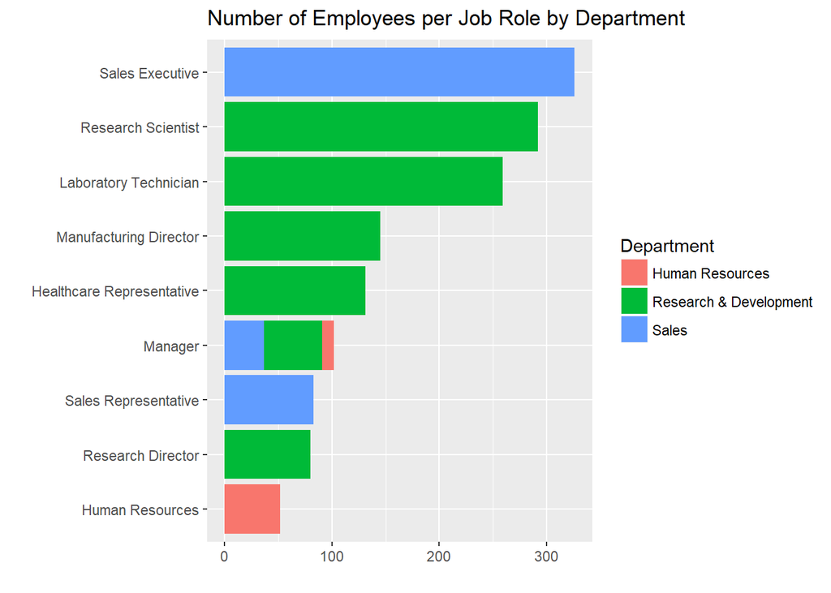

```r
ggplot(data=as.data.frame(table(attrit$Department,attrit$JobRole,dnn=list("Department","JobRole"))), aes(x= reorder(JobRole,Freq),y=Freq, fill = Department)) +
geom_bar(stat="identity") + coord_flip() + ggtitle("Number of Employees per Job Role by Department") + xlab("") + ylab("")
```

##### The Job Role “Manager” is the only Job Role that is in multiple departments

##### To aid analysis the values of JobRole for the Managers will be recoded

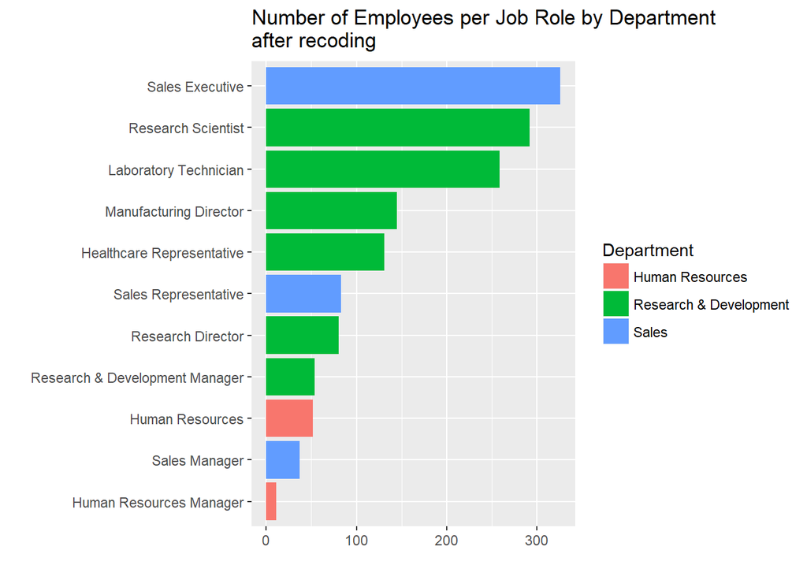

```r
# Recode Managers
attrit$JobRole <-with(attrit, ifelse(attrit$JobRole == "Manager",paste(attrit$Department,attrit$JobRole), as.character(attrit$JobRole)))
attrit$JobRole <- as.factor(attrit$JobRole)
ggplot(data=as.data.frame(table(attrit$Department,attrit$JobRole,dnn=list("Department","JobRole"))), aes(x= reorder(JobRole,Freq),y=Freq, fill = Department)) +
geom_bar(stat="identity") + coord_flip() + ggtitle("Number of Employees per Job Role by Department \nafter recoding") + xlab("") + ylab("")
```

```r
#Recode the variable "JobRole" to a numeric value for modeling
attrit$JRCode[attrit$JobRole=="Healthcare Representative"] <- 1L
attrit$JRCode[attrit$JobRole=="Human Resources"] <- 2L
attrit$JRCode[attrit$JobRole=="Laboratory Technician"] <- 3L
attrit$JRCode[attrit$JobRole=="Manufacturing Director"] <- 4L
attrit$JRCode[attrit$JobRole=="Research Director"] <- 5L
attrit$JRCode[attrit$JobRole=="Sales Executive"] <- 6L
attrit$JRCode[attrit$JobRole=="Research Scientist"] <- 7L
attrit$JRCode[attrit$JobRole=="Sales Representative"] <- 8L
attrit$JRCode[attrit$JobRole=="Human Resources Manager"] <- 9L
attrit$JRCode[attrit$JobRole=="Research & Development Manager"] <- 10L
0.0008
```

```
## [1] 8e-04
```

```r
#Create a dataframe of current employees only
noattrit <- attrit[attrit$Attrition=="No",]
noattrit$Attrit <- NULL
```

### Job Roles

#### Note: All analysis has been performed on employees only (No attrition participants

#### Key Findings

##### 1) Manager Job Role:

##### a) only job role that exists in all departments. All other job roles are unique to a department.

##### b) have the longest average duration at the company.

##### 2) Managers and Directors

##### a) tend to be older than people in other job roles.

##### b) have higher Job Levels.

##### c) have higher Monthly Income

##### 3) Manufacturing Director

##### a) the only Job Role where Males do not outnumber Females.

##### 4) Human Resource Manager

##### a) is the only Role which does not have ‘Low’ level of job involvement

##### b) No PhDs (characteristic in common with Sale Reps)

##### c) All HR Managers have some College level education (a characteristic unique to this Job Role)

##### 5) Sales Reps and Reseach Scientists

##### a) have the lowest Job Levels.

##### 6) Sales Reps

##### a) is the only Job Role which has no employees with NumWorked = 9!!

##### b) have the lowest average duration at the company.

##### c) change managers most frequently, while directors and managers tend to stay with the same manager for a longer time.

##### d) No PhDs (characteristic in common with HR Managers)

##### e) the highest percentage of employees with college-level education (25%)

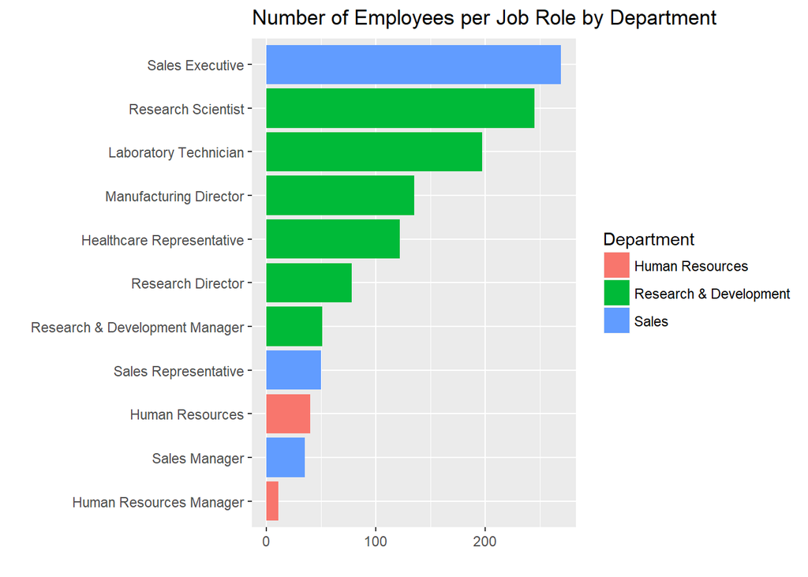

```r
ggplot(data=as.data.frame(table(noattrit$Department,noattrit$JobRole,dnn=list("Department","JobRole"))), aes(x= reorder(JobRole,Freq),y=Freq, fill = Department)) +
geom_bar(stat="identity") + coord_flip() + ggtitle("Number of Employees per Job Role by Department") + xlab("") + ylab("")
```

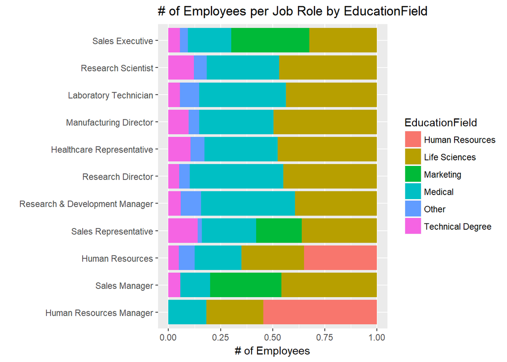

```r
ggplot(data=as.data.frame(table(noattrit$JobRole,noattrit$EducationField,dnn=list("JobRole","EducationField"))), aes(x= reorder(JobRole,Freq),y=Freq, fill = EducationField)) +
geom_bar(stat="identity",position="fill") + coord_flip() + ggtitle("# of Employees per Job Role by EducationField") + xlab("") + ylab("# of Employees")
```

##### Observations

##### 1.All Departments have a mix of educational fields

##### 2.People with Education in Marketing only work in the Sales Department

##### 3.People with Education in Human Resources work in the Human Resources Department

##### 4.R&D is predominantly composed of people with Life Sciences and Medical Education

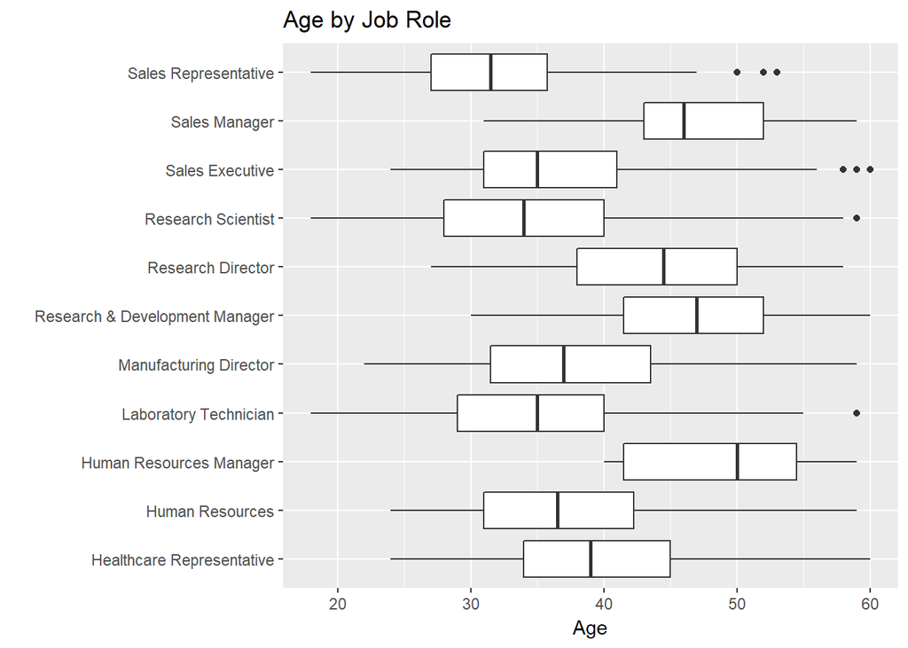

```r
noattrit$JobRole <-with(noattrit, ifelse(noattrit$JobRole=="Manager", paste(noattrit$Department,noattrit$JobRole), as.character(noattrit$JobRole)))
ggplot(data=noattrit,aes(x= JobRole,y=Age)) +
geom_boxplot() + coord_flip() + ggtitle("Age by Job Role") + xlab("")+ylab("Age")
```

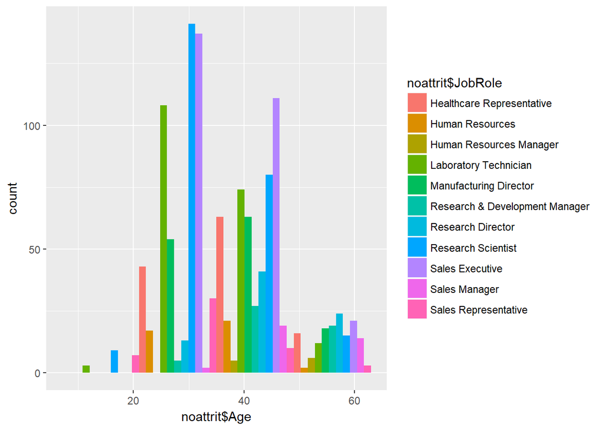

```r
 ggplot(data=noattrit, aes(x=noattrit$Age,fill=noattrit$JobRole)) + geom_histogram(position = "dodge",bins=4)
```

```r
  summary(noattrit$Age)
```

```
##    Min. 1st Qu.  Median    Mean 3rd Qu.    Max.
##   18.00   31.00   36.00   37.56   43.00   60.00
```

```r
  results <- lm(noattrit$JRCode~noattrit$Age)
summary(results)
```

```
##
## Call:
## lm(formula = noattrit$JRCode ~ noattrit$Age)
##
## Residuals:
##     Min      1Q  Median      3Q     Max
## -4.0652 -2.0573  0.9379  1.9400  4.9427
##
## Coefficients:
##               Estimate Std. Error t value Pr(>|t|)
## (Intercept)  5.0494530  0.2910012  17.352   <2e-16 ***
## noattrit$Age 0.0002632  0.0075984   0.035    0.972
## ---
## Signif. codes:  0 '***' 0.001 '**' 0.01 '*' 0.05 '.' 0.1 ' ' 1
##
## Residual standard error: 2.31 on 1196 degrees of freedom
##   (35 observations deleted due to missingness)
## Multiple R-squared:  1.003e-06,  Adjusted R-squared:  -0.0008351
## F-statistic: 0.0012 on 1 and 1196 DF,  p-value: 0.9724
```

##### Observations

##### 1. Managers and Directors tend be older than people in other roles

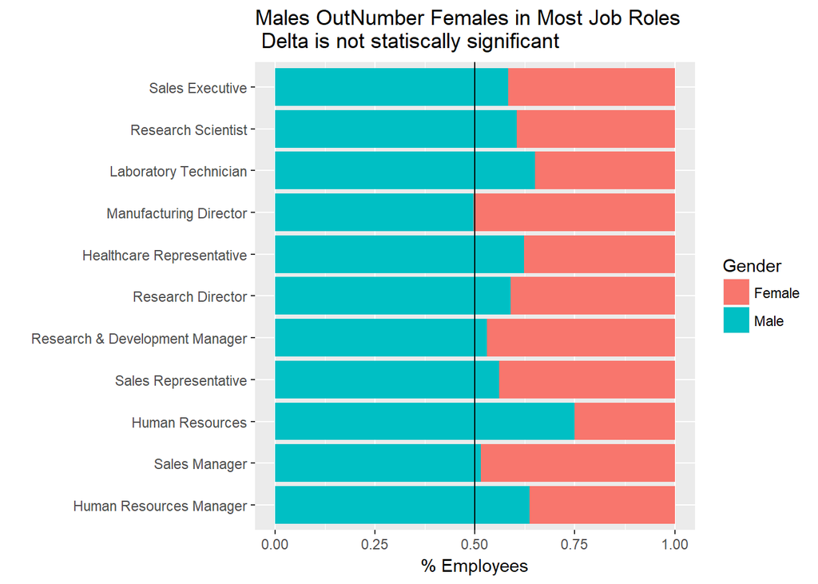

```r
ggplot(data=as.data.frame(table(noattrit$JobRole,noattrit$Gender,dnn=list("JobRole","Gender"))), aes(x= reorder(JobRole,Freq),y=Freq, fill = Gender)) +
geom_bar(stat="identity",position="fill") + coord_flip() + ggtitle("Males OutNumber Females in Most Job Roles \n Delta is not statiscally significant") + xlab("") + ylab("% Employees") + geom_hline(data=noattrit, aes(yintercept = .50), colour="black")
```

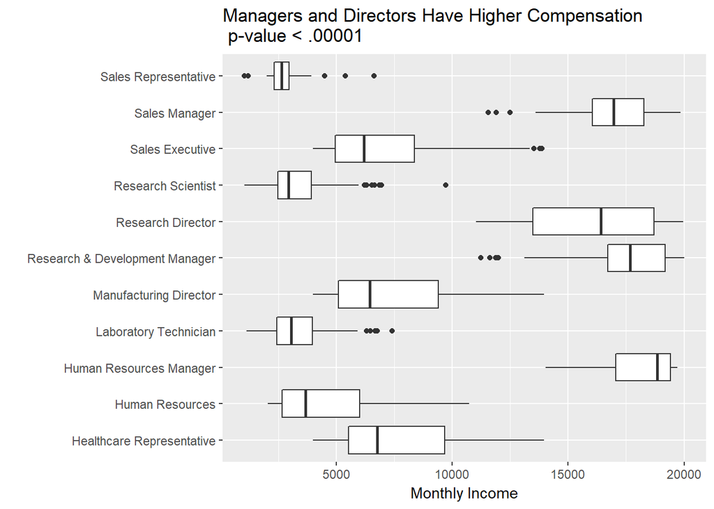

```r
ggplot(data=noattrit,aes(x= JobRole,y=MonthlyIncome,group=JobRole)) + geom_boxplot() + coord_flip() + ggtitle("Managers and Directors Have Higher Compensation \n p-value < .00001") + xlab("")+ylab("Monthly Income")
```

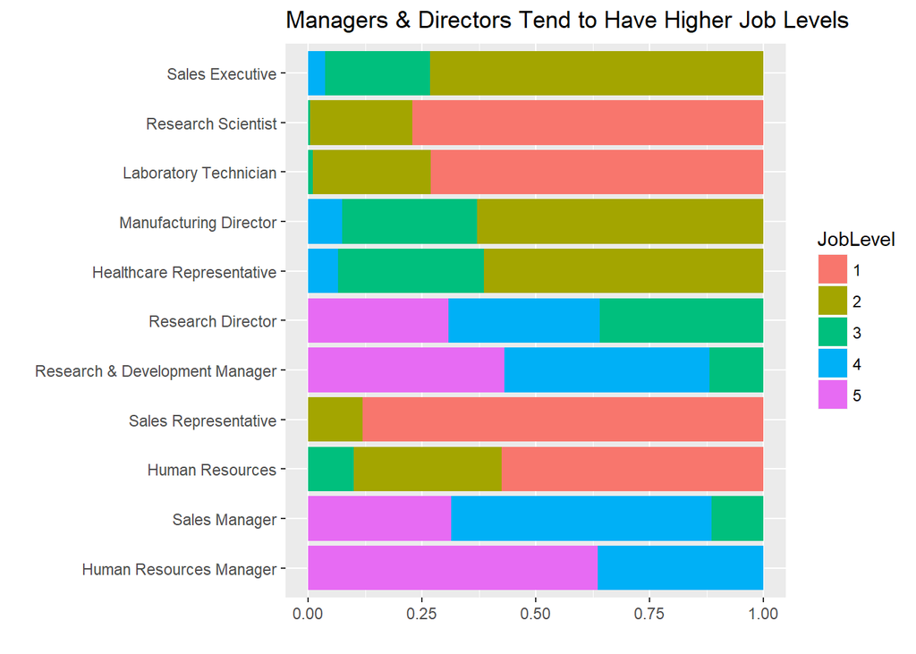

```r
 ggplot(data=as.data.frame(table(noattrit$JobRole,noattrit$JobLevel,dnn=list("JobRole","JobLevel"))), aes(x= reorder(JobRole,Freq),y=Freq, fill = JobLevel)) + geom_bar(stat="identity",position="fill") + coord_flip() + ggtitle("Managers & Directors Tend to Have Higher Job Levels") + xlab("") + ylab("")
```

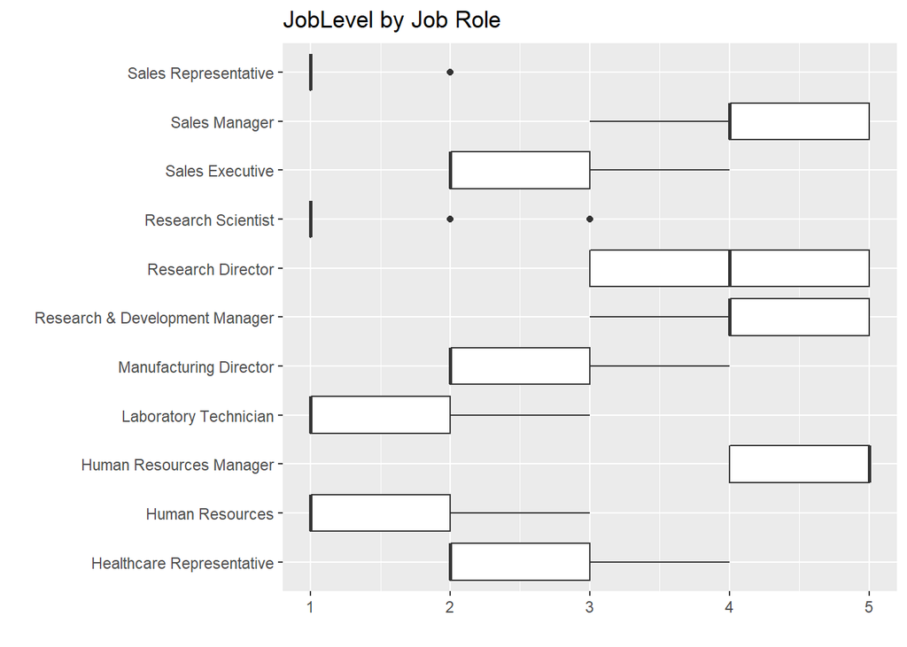

```r
ggplot(data=noattrit,aes(x= JobRole,y=JobLevel)) + geom_boxplot() + coord_flip() + ggtitle("JobLevel by Job Role") + xlab("")+ylab("")
```

```r
results <- lm(noattrit$JRCode~noattrit$JobLevel)
summary(results)
```

```
##
## Call:
## lm(formula = noattrit$JRCode ~ noattrit$JobLevel)
##
## Residuals:
##    Min     1Q Median     3Q    Max
## -4.526 -1.795  0.718  2.205  4.718
##
## Coefficients:
##                   Estimate Std. Error t value Pr(>|t|)
## (Intercept)        4.55089    0.14517  31.349  < 2e-16 ***
## noattrit$JobLevel  0.24371    0.06191   3.937 8.74e-05 ***
## ---
## Signif. codes:  0 '***' 0.001 '**' 0.01 '*' 0.05 '.' 0.1 ' ' 1
##
## Residual standard error: 2.295 on 1196 degrees of freedom
##   (35 observations deleted due to missingness)
## Multiple R-squared:  0.01279,    Adjusted R-squared:  0.01197
## F-statistic:  15.5 on 1 and 1196 DF,  p-value: 8.742e-05
```

###### Observations:

###### 1. Managers and Directors have higher Job Levels.

###### 2. Sales Reps and Research Scientists have the lowest Job Levels.

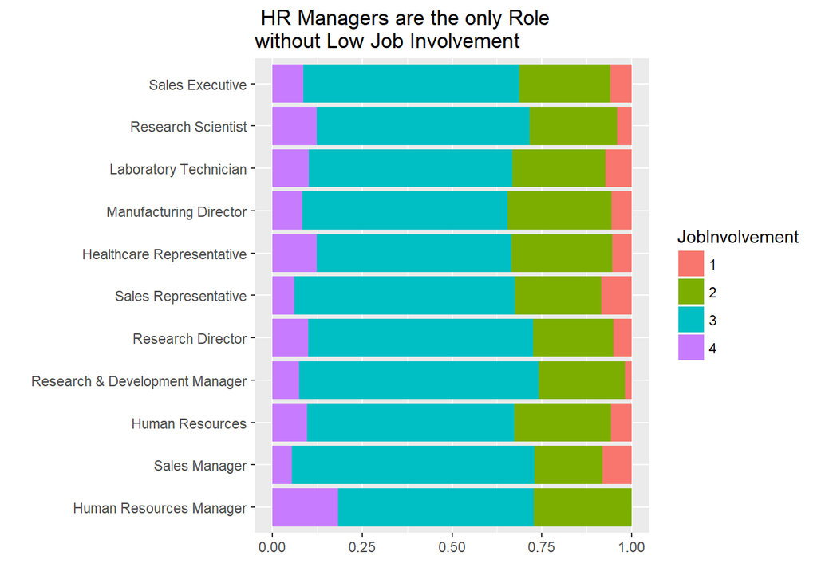

```r
ggplot(data=as.data.frame(table(attrit$JobRole,attrit$JobInvolvement,dnn=list("JobRole","JobInvolvement"))), aes(x= reorder(JobRole,Freq),y=Freq, fill = JobInvolvement)) +
geom_bar(stat="identity",position="fill") + coord_flip() + ggtitle(" HR Managers are the only Role \nwithout Low Job Involvement") + xlab("") + ylab("")
```

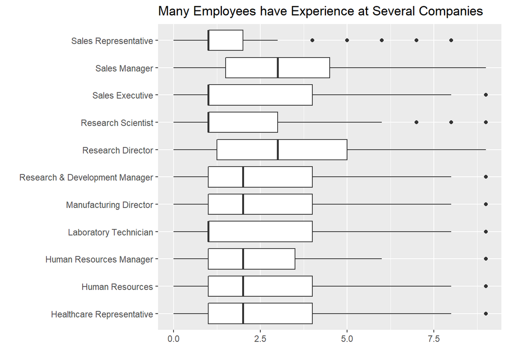

```r
ggplot(data=noattrit,aes(x= JobRole,y=noattrit$NumCompaniesWorked)) +
geom_boxplot() + coord_flip() + ggtitle("Many Employees have Experience at Several Companies") + xlab("")+ylab("")
```